# Advance layoff notices and aggregate job loss

Converted from PDF `Krolikowski-AdvanceLayoffNotices-2024-JAE.pdf` · 19 pages · anchors: page `#pN`, block `#pN-bK`

Page 1

Received: 5 October 2022 Revised: 14 March 2023 Accepted: 20 July 2023

DOI: 10.1002/jae.3032

#### **R E S E A R C H A R T I C L E**

## **Advance layoff notices and aggregate job loss**

#### **Pawel M. Krolikowski Kurt G. Lunsford**

Federal Reserve Bank of Cleveland, Cleveland, Ohio, USA

**Correspondence** Kurt G. Lunsford, Federal Reserve Bank of Cleveland, 1455 East 6th St, Cleveland, OH 44114, USA. Email: kurt.lunsford@clev.frb.org

#### **Summary**

We collect data from Worker Adjustment and Retraining Notification (WARN)

Act notices and establish their usefulness as an indicator of aggregate job loss. The number of workers affected by WARN notices (“WARN layoffs”) leads

state-level initial unemployment insurance claims and unemployment rate (UR)

and private employment changes. WARN layoffs comove with aggregate layoffs from Mass Layoff Statistics and the Job Openings and Labor Turnover Survey

but are timelier and cover a longer sample. In a vector autoregression, changes

in WARN layoffs lead UR changes and job separations. Finally, they improve pseudo real-time forecasts of the UR and private employment changes.

#### **KEYWORDS**

dynamic factor model, mass layoffs, unemployment, WARN Act

#### **1 INTRODUCTION**

The unemployment rate is one of the most widely recognized business cycle indicators. In turn, job separations are important for understanding unemployment fluctuations, especially during economic turning points.<sup>1</sup> Therefore, policymakers and economists benefit from high-frequency and timely measures of job separations.<sup>2</sup>

In this paper, we develop and maintain a timely measure of layoffs using daily establishment-level data from Worker Adjustment and Retraining Notification (WARN) Act notices. Further, we present evidence that supports the use of WARN data for monitoring job separations, the unemployment rate, and other labor market variables in real time.

We collect data from advance layoff notices filed under the WARN Act. This act requires larger employers to notify affected workers at least 60 days before a potential mass layoff. We assemble about 75,000 WARN notices from 33 US states. For many large states our data begin in the 1990s. We update these data twice a month and aggregate them into an unbalanced monthly panel of state-level “WARN layoffs,” defined as the number of workers affected by WARN notices. We publish the data in real time on openICPSR at https://doi.org/10.3886/E155161 (Krolikowski & Lunsford, 2022). We obtain initial measures of WARN layoffs for the previous month about 2 weeks after the end of that month.

Four findings establish these WARN data as a useful indicator of aggregate job loss. First, in-sample state-month panel regressions show that increases in WARN layoffs predict increases in initial unemployment insurance (UI) claims and the unemployment rate and decreases in employment. The strongest predictions occur over the 2-month horizon, consistent with the 60 days' notice required by the WARN Act.

1Elsby et al. (2009) and Barnichon (2012) find that separations account for about 40% of unemployment fluctuations on average, and the role of separations is more pronounced at the onset of recessions. Coles and Moghaddasi Kelishomi (2018) present a model in which job separations drive “the large variation in unemployment over the cycle.”

2The need for high-frequency and timely labor market data was highlighted during the onset of the 2020 recession, as discussed in Cajner et al. (2020), Chetty et al. (2020), Coibion et al. (2020), Forsythe et al. (2020), Dvorkin and Isaacson (2021), and Kurmann et al. (2021). Our paper focuses on job separations and complements this work.

wileyonlinelibrary.com/journal/jae © 2024 John Wiley & Sons, Ltd. *J Appl Econ*. 2024;39:462–480. **462**

Page 2

Second, aggregated WARN data track published layoffs well but are timelier and cover a longer period. We aggregate the unbalanced state-level data to a national-level indicator of job loss (the “WARN factor”) using a dynamic factor model (DFM) that we estimate with the algorithm in Ba ´nbura and Modugno (2014). WARN layoffs implied by our factor are highly correlated with the number of initial UI claimants from the defunct Mass Layoff Statistics (MLS) program and the number of layoffs and discharges among large establishments from the Job Openings and Labor Turnover Survey (JOLTS). Further, WARN layoffs lead these two indicators during the 2008–2009 recession. Our data also extend beyond May 2013 (when the MLS program was eliminated) and before December 2000 (when JOLTS began), and they are timelier than JOLTS data, which are published with a 2-month lag.

Third, in the vector autoregression (VAR) from Barnichon and Nekarda (2012), changes in WARN layoffs implied by our factor lead changes in the unemployment rate and the job separation rate from the Current Population Survey (CPS). Impulse response functions (IRFs) from this VAR show that the separation rate and initial UI claims rise immediately following a surprise increase in WARN layoffs. Consistent with these IRFs, the unemployment rate rises and changes in private employment fall, with statistically significant responses beyond the WARN Act's 60-day notice period. There is no short-term movement in the job finding rate, consistent with WARN data informing job separations.

Fourth, changes in WARN layoffs improve forecasts of the national unemployment rate and private employment changes in pseudo real time. We use the VAR and Barnichon and Nekarda's (2012) flows model to forecast the unemployment rate, and we also use the VAR to forecast private employment changes. Adding changes in WARN layoffs implied by our factor to these models improves forecast accuracy beyond 1 month for the unemployment rate and 6 months for private employment changes. For both variables, we reduce root mean squared prediction errors (RMSPEs) by 10% or more at longer horizons.

Our findings support the recent use of WARN data by other researchers, although none of that work evaluates WARN notices as an indicator of aggregate job loss. For example, Hall and Kudlyak (2020) use WARN notices from three states to measure mass layoffs. Kudlyak and Wolcott (2020) use WARN notices from several states to document the nature and timing of layoffs at the onset of the 2020 recession. Hernández-Murillo and Krolikowski (2020) study advance notice timing, industry mix, and geography of WARN notices in four Midwestern states during the 2020 recession. WARN data also provide a timely indicator that complements initial UI claims, which have at least two shortcomings. First, initial claims only proxy for layoffs because the UI take-up rate is well below 100% and moves over the cycle.<sup>3</sup> Second, during the pandemic, processing delays, duplicate claims, and fraud made initial UI claims less accurate than in the past (Cajner et al., 2020).

#### **2 THE WARN DATA**

#### **2.1 The WARN Act**

The WARN Act seeks to provide workers with sufficient time to begin new job searches or to retrain. The act requires employers with 100 or more employees to provide their workers with at least 60 days' written notice prior to layoff. WARN notification is triggered by large, permanent reductions in establishment employment, defined in two ways. First, a “plant closing” is when an employment site is shut down and 50 or more full-time workers lose their jobs. Second, a “mass layoff” is when employment is reduced by 500 or more full-time workers at a given site or by 50 to 499 full-time workers if they make up at least one third of the employer's workforce.<sup>4</sup> The act also applies when an employer announces that a temporary layoff (less than 6 months) becomes a permanent one. The act requires notices to include the name and address of the affected employment site, the expected date of the first layoff, and the anticipated number of affected employees.

The penalty for issuing too little notice can be severe. If an employer fails to give workers 60 days' notice for a qualifying WARN event, they are liable to each employee for back pay and benefits for the period of violation, up to 60 days. We discuss details about the act and the nonpecuniary costs associated with unrealized WARN notices in Appendix A.1 in the supporting information.

3See Blank and Card (1991), Vroman (2009), and Auray et al. (2019) for evidence about and discussion of the former. Hobijn and ¸Sahin (2011) find that the UI take-up rate rose during the 2008–2009 recession.

4The one-third rule exempts many large layoffs from coverage by the act according to GAO (1993) and, as a result, employers are more likely to issue notices of plant closures than mass layoffs (GAO, 2003).

KROLIKOWSKI and LUNSFORD **463**

Page 3

There exist exceptions to issuing less than 60 days' notice. For example, the “unforeseeable business circumstances” exception applies when business circumstances change suddenly and unexpectedly. Even when employers file with an exception, however, the Department of Labor insists that notices must be given as soon as is “practicable” and the employer must provide a statement for the reason for reducing the notification period. We discuss two other narrow exceptions in Appendix A.1 in the supporting information.

Some states and localities have passed legislation that expands the federal WARN Act. For example, since February 2009, NY state requires that employers provide 90 days' advance notice and it requires WARN notices from smaller firms and in anticipation of smaller layoff events (NY WARN, 2019).

#### **2.2 Data collection, revisions, and creating a monthly panel**

We collect establishment-level WARN notices from state employment offices, via websites and contacting state officials. We often extend publicly available WARN data by using digital archives of the internet and documents from state officials. We discuss details about our data collection efforts and missing data in Appendix A.2 in the supporting information.

We currently update our WARN database in the middle of the month and at the end of the month. We consider the number of workers affected by WARN notices in a given state and month as complete when we observe a WARN notice for that state in a subsequent month. We observe the most recent WARN notices at different times for each state because of different WARN release schedules and infrequent WARN notices for smaller states. In Appendix A.2 in the supporting information, we discuss extending historical data and our updating schedule, and we highlight the timeliness of our data relative to the employment report (BLS, 2022) and initial UI claims.

We remove revisions of original WARN notices for two reasons. First, including original and revised notices would overcount the number of affected workers. Second, including only original notices improves the timeliness of our data and minimizes data revisions. However, only some states in our sample differentiate revised notices from original notices. For other states, we identify revised notices with an algorithm, which removes no more than 3% of any state's notices, as described in Appendix A.2 in the supporting information.

To obtain a monthly state panel, we sum the expected number of affected workers by WARN notices across establishments based on notice dates in each state-month cell and seasonally adjust this series for each state using the model in Wright (2013, pg. 80). We refer to the number of workers affected by WARN notices in a given state and month as “WARN layoffs,” although firms do not have to follow through with the announced layoffs. We drop several states from our sample due to restrictions on WARN data, and our analyses use several published data sets, as discussed in Appendix A.2 in the supporting information.

#### **2.3 Monthly panel summary statistics**

As of December 30, 2021, our WARN data include about 75,000 WARN notices affecting over 8 million workers, which implies that the average WARN notice affects about 110 workers.<sup>5</sup> About 55,000 notices occurred before January 2020 and about 20,000 occurred afterwards. Over the years 2014 to 2019, when the sample of states did not change, there were roughly 270,000 workers affected by 2600 WARN notices each year.

Table 1 presents our baseline sample of states and some summary statistics about WARN layoffs. We collect and post WARN layoffs for 33 states, as mentioned in Section 1, but we drop ID, KY, OK, UT, and WV from our analysis because they contain many months with zero WARN layoffs. MI is the first state to enter our sample in January 1990, and by January 2000, we have 13 states; by January 2006, we have 23 states, and by January 2019, we have 27 states in our sample.<sup>6</sup> States do not publish their most recent data at the same time, as discussed in Section 2.2. Hence, the end date for each state can differ, although most large states completed reporting WARN data through November 2021 when we collected data at the end of December. We present summary statistics for several published datasets and WARN layoffs in

5About 35 (22)% of employers filing WARN notices in our sample anticipate fewer than 50 (25) layoffs. These filings include fewer layoffs than the federally mandated threshold for issuing a WARN notice, which is partly explained by geographic variation in legislation, as mentioned in Section 2.1, and partly explained by employer confusion about when a WARN notice is required, as documented by GAO (1993, 2003). Further, Ehrenberg and Jakubson (1990) find that Pennsylvanian employers filed notices even when WARN did not apply.

6WARN data for the eight most populous states in our sample—CA, TX, FL, NY, PA, IL, OH, and NC—start in 1/2006, 1/1999, 1/1998, 10/2001, 1/2001, 1/1999, 7/1996, and 5/1996, respectively. SC is the only state that has data for some period and then drops out due to missing data.

KROLIKOWSKI and LUNSFORD **464**

Page 4

**TABLE 1** Summary statistics of state-month panel of the number of workers affected by WARN notices.

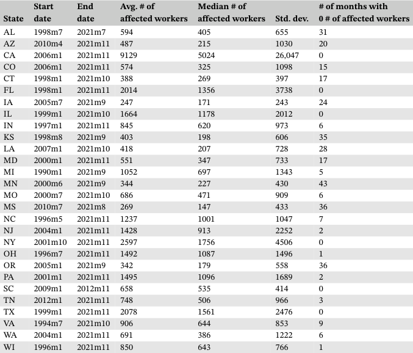

NOTE: complex table shown as an image of the PDF; the text below is a rough machine extraction and may be mis-aligned.

**extracted text (unreliable layout)**

*Note*: We use 28 states in our analysis. From the 50 US states, we drop AR, DE, HI, ME, MT, NH, NV, SD, VT, and WY due to data accessibility restrictions. We drop GA and NE because they did not have notice dates. We drop MA because we could not obtain historical data. We drop AK, ND, NM, and RI because the time series could not be seasonally adjusted. Finally, we collect data for ID, KY, OK, UT, and WV but drop these states from our analysis sample because they contain many months with zero workers affected by WARN notices. SC is the only state that has data for some period and then drops out of our sample. SC drops out because subsequent to November 2012, no notice month is available. Data are as of the end of December 2021. Summary statistics for seasonally adjusted data. See Section 2.3 for details. Abbreviation: WARN, Worker Adjustment and Retraining Notification.

Appendix A.3 in the supporting information. In this appendix in the supporting information, we also show that state-level WARN layoffs are counter-cyclical but somewhat noisy. Finally, we show that WARN notices tilt toward manufacturing establishments.

#### **2.4 WARN data coverage**

The WARN Act covers firms that represent a majority of employment and our recent sample of states with WARN data covers most of the United States. According to the Business Dynamics Statistics from the US Census Bureau (Census, 2019), between 1990 and 2019, 60% to 67% of employment was in firms with at least 100 workers. As such, the WARN Act covers up to two thirds of all employment.<sup>7</sup> In addition, the initial UI claims in our sample of states in 2018 cover almost 85% of national initial UI claims.

Additionally, WARN data cover a small but nontrivial fraction of aggregate job loss, as measured by several indicators. First, for state-month observations in our sample, the median number of workers affected by WARN notices is about 20%

7Temporary and seasonal employment is not covered by the WARN Act, but this employment is a relatively small part of the economy (OECD, 2020).

KROLIKOWSKI and LUNSFORD **465**

Page 5

**FIGURE 1** Number of Worker Adjustment and Retraining Notification (WARN) notices by the number of days of advance notice. *Note:* Establishment-level WARN notice data from January 1990 to November 2021. This histogram excludes Arizona (2019m7 and on), Kansas, Minnesota, New Jersey, and Pennsylvania, from our sample, because we do not observe the difference between layoff and notice dates. Total number of observations is 75,490 of which 20,165 have notice dates after 2019. Outliers are dropped at the 1% level on both sides of the advance notice distribution. See Section 2.5 for details.

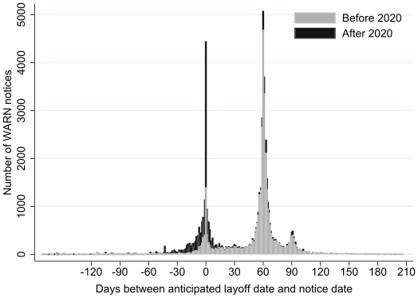

NOTE: figure/graphic rendered as an image from the PDF; its content is not machine-readable text. Caption (if any) follows as the next block.

of the median number of initial UI claimants from plants in the MLS (Table A1, rows 1 and 2).<sup>8</sup> Second, WARN layoffs cover about 1.5% of the approximately 17 million annual private-sector layoffs and discharges as measured by JOLTS from 2014 through 2018 (JOLTS, 2022). Third, WARN notices cover about 2% of all initial UI claims, which were roughly 13 million over the years 2014 to 2018 (Claims, 2022).

#### **2.5 How much advance notice do employers give?**

Our WARN data will help assess current and future labor market conditions if employers issue timely WARN notices. In this section, we document the advance notice issued by employers, as measured by the number of days between the date a notice was filed and the anticipated layoff date for each WARN notification.

Advance notice data before 2020 have three features that suggest that WARN notices provide substantial advance notice, as shown in Figure 1 (gray bars). First, there is a large spike at 60 days, consistent with the 60 days' advance notice required by law. Second, almost two thirds of all notices provide 40 to 80 days of advance notice. Third, there is a substantial number of WARN notices with about 90 days' advance notice because NY has required 90 days' advance notice since February 2009, as discussed in Section 2.1. The spike at 0 days reflects employers that file the WARN notice the same day they began laying off workers.

#### **3 WARN AS A LABOR MARKET INDICATOR**

#### **3.1 Preliminary evidence**

We present preliminary evidence that WARN notices move together with, and slightly lead, initial UI claims from the MLS program and layoffs and discharges from JOLTS. The slight lead time is consistent with the 60 days' notice required by law and our evidence about advance notice in Section 2.5.

8This coverage is broadly consistent with the findings by GAO (2003).

KROLIKOWSKI and LUNSFORD **466**

Page 6

**FIGURE 2** Number of workers affected by Worker Adjustment and Retraining Notification (WARN) notices and Mass Layoff Statistics (MLS) initial claimants. *Note:* The number of seasonally adjusted individuals affected by WARN notices leads the number of MLS initial claimants during the 2008-2009 recession. WARN data are for a balanced panel of states as of January 2006. MLS data are for the same set of states. Initial claimant data from MLS end in May 2013. Data are seasonally adjusted using the procedure in Wright (2013, pg. 80). Shading represents NBER recession dates. See Section 3.1 for details.

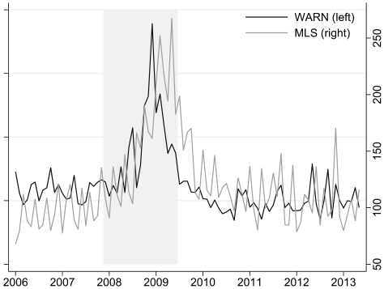

NOTE: figure/graphic rendered as an image from the PDF; its content is not machine-readable text. Caption (if any) follows as the next block.

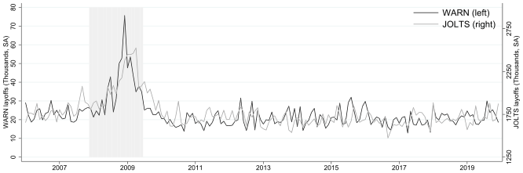

NOTE: figure/graphic rendered as an image from the PDF; its content is not machine-readable text. Caption (if any) follows as the next block.

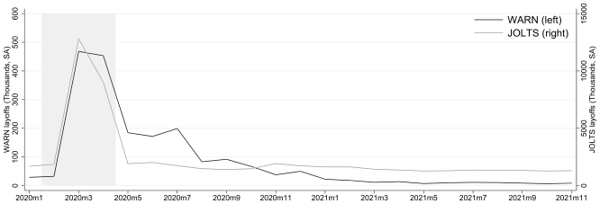

NOTE: figure/graphic rendered as an image from the PDF; its content is not machine-readable text. Caption (if any) follows as the next block.

**FIGURE 3** Number of workers affected by Worker Adjustment and Retraining Notification (WARN) notices and Job Openings and Labor Turnover Survey (JOLTS) layoffs and discharges. *Note:* The number of seasonally adjusted individuals affected by WARN notices and the number of layoffs and discharges in JOLTS (total private) move together. Both series are in thousands. In the top panel, the sample is January 2006 to December 2019, and in the bottom panel, it is since January 2020. Vertical axes differ in the two panels. WARN data are for a balanced panel of states as of January 2006. JOLTS data are for the nation. JOLTS seasonally adjusted data are from the BLS. Shading represents NBER recession dates. See Section 3.1 for details.

Figure 2 shows the seasonally adjusted aggregate number of workers affected by WARN notices and the number of initial UI claimants as covered by the MLS program. The figure begins in January 2006 and includes only those states that have data available on WARN notices during that month to maintain a balanced sample of states.<sup>9</sup> The figure shows that WARN layoffs tend to move with MLS initial claims, but the latter is noisier than the former. Also, during the 2008–2009

9We start in January 2006 because CA enters our sample then, and we have 23 states in our sample.

KROLIKOWSKI and LUNSFORD **467**

Page 7

recession, WARN layoffs rose sharply in October 2008, 3 months before the sharp rise in MLS initial claims. And WARN layoffs peaked in December 2008 and were on a clear decline before MLS initial claims peaked in May 2009.

WARN layoffs and the number of layoffs and discharges from JOLTS tend to move together, as shown in Figure 3. Moreover, during the 2008–2009 recession, the number of workers affected by WARN notices rose sharply in October 2008, 2 months before the sharp rise in JOLTS layoffs in December 2008 (top panel). The number of layoffs and discharges in JOLTS rises through April 2009, whereas WARN layoffs peak in December 2008 and decline considerably by April 2009. During the 2020 recession, WARN layoffs rise sharply in March, similar to JOLTS layoffs and both have since declined (bottom panel).

#### **3.2 State-level evidence with regression analyses**

We find that WARN notices help predict several state-level lab market indicators. To assess the predictive content of WARN information, we estimate the following equation:

**equation / math rendering (image)**

NOTE: contains mathematical notation; text above is the PDF text layer and symbols may be mis-extracted. Image shows the original.

**equation / math rendering (image)**

NOTE: contains mathematical notation; text above is the PDF text layer and symbols may be mis-extracted. Image shows the original.

**equation / math rendering (image)**

NOTE: contains mathematical notation; text above is the PDF text layer and symbols may be mis-extracted. Image shows the original.

**equation / math rendering (image)**

NOTE: contains mathematical notation; text above is the PDF text layer and symbols may be mis-extracted. Image shows the original.

**equation / math rendering (image)**

NOTE: contains mathematical notation; text above is the PDF text layer and symbols may be mis-extracted. Image shows the original.

in which *s* denotes state and *t* denotes month; *𝑦s,t* is initial UI claims, the change in the unemployment rate or the change in private employment; *𝛼s* are state fixed effects; *WARNs,t*−*i* is WARN layoffs and its lags; and *Xs,t*−*i* controls for lags of the left-hand-side variable, *𝑦s,t*−*i*, and lags of the other outcome variables. Because the WARN Act requires 60 days' notice, and in Section 2.5, we find that most notices occur about 2 months before the anticipated layoff event, we include two lags, so that *i* = {1*,* 2}. We weight the regressions by state employment in each state in each month because a regression of squared residuals on the inverse of state employment, as suggested by Solon et al. (2013), indicates significant heteroskedasticity in our data. We omit month fixed effects from Equation (1) because in real time, information about month *t* is not available in month *t*.

The number of workers affected by WARN notices leads state-level labor market indicators by 1 to 2 months. These effects are statistically significant and suggest that WARN data have predictive content even after controlling for initial UI claims, unemployment rates, and private employment. Table 2 presents the results. Column (1) suggests that if WARN layoffs in state *s* rise by 1000 this month (almost a one standard deviation increase), we expect initial UI claims in state *s* to rise next month by about 270 (≈63×4*.*3), after controlling for other labor market variables. This response of initial claims is small compared with the standard deviation of monthly changes in state-level initial UI claims (about 1900). If WARN layoffs in state *s* rise by 1000 this month, we expect the change in the unemployment rate to increase by about 0.005pp

**TABLE 2** WARN as a leading state-level indicator. **(1) (2) (3) *uics,t* 𝚫*urs,t* 𝚫*pes,t*** *WARNs,t*−1 63** 0.0028* −1278*** (28) (0.0014) (172) *WARNs,t*−2 −48 0.0019 −843*** (43) (0.0014) (283) *p*-value *WARNs,t*−*i* = 0 0.026 0.15 2 × 10<sup>−</sup><sup>7</sup>

Observations 6047 6,047 6,047 *R*-squared 0.98 0.61 0.47

*Note*: WARN notices lead state-level initial UI claims, changes in the unemployment rate, and changes in private employment. The sample is January 1990 to December 2019. All columns include state fixed effects and controls for two lags of initial UI claims (*uics,t*), changes in the unemployment rate (Δ*urs,t*), and changes in private employment (Δ*pes,t*). Initial UI claims represent the average weekly claims in a month. Therefore, to obtain the approximate effect of WARN layoffs on monthly initial UI claims, we multiply the coefficients in column (1) by 4.3 in the main text. Regressions are weighted by employment. Standard errors clustered at the state level. See Section 3.2 for details. Abbreviation: WARN, Worker Adjustment and Retraining Notification.****p <* 0*.*01.

***p <* 0*.*05.

**p <* 0*.*1.

KROLIKOWSKI and LUNSFORD **468**

Page 8

(column 2), and private employment growth to slow by about 2100 (column 3), over the next 2 months. Both of these effects are also quantitatively small compared with the standard deviation of unemployment rate (private employment) changes, which is about 0.1pp (17,400).

#### **4 NATIONAL-LEVEL AGGREGATION WITH A DFM**

In this section, we aggregate our state-level panel data to a national-level labor market indicator. Aggregating our data is challenging because the state-level panel is unbalanced in two ways. First, the state-level data do not all begin at the same time (see Section 2.3). Second, states have nonsynchronized data releases (see Section 2.2), leading to a “ragged” edge problem in real time (Ba ´nbura et al., 2013). We could restrict our sample to those states that are available at a point in time and simply sum those states going forward (as we do in Figures 2 and 3), but this approach limits both the historical time-series and the cross-sectional observations and the ragged edge problem remains.

To manage these data challenges, we model our unbalanced panel with a DFM, which we estimate with the expectation maximization (EM) algorithm in Ba ´nbura and Modugno (2014). Our DFM assumes that the state-level data share a common, national-level factor or “WARN factor,” scaled by state-specific factor loadings. In addition, the DFM assumes that the state-level data have state-specific shocks. Intuitively, the WARN factor explains the common comovements in the state-level data while filtering out the state-specific shocks. When states have missing observations, the EM algorithm uses the common comovements of the nonmissing states to estimate the WARN factor. DFMs are common, and other recent research has used them to estimate the common comovements in disaggregated price data (Luciani, 2020) in disaggregated wage data (Ahn et al., 2020) and in a variety of inflation expectations data (Ahn & Fulton, 2020). We describe our DFM and the EM algorithm in this section and provide details in Appendix B in the supporting information.

We first prepare the data. To reduce excess kurtosis in *WARNs,t*, we use the log transformation *xs,t* = ln(*WARNs,t*). If *WARNs,t* = 0, we call the log of the observation an outlier. We treat outliers as missing as in Ng (2020), and our EM algorithm ignores these observations. Because zeros typically occur in smaller states, treating these observations as missing puts more weight on larger states for estimating the WARN factor in the corresponding months. After dropping 0s and taking logs, we make no other adjustments for outliers. We use *s ⊆*{1*,* … *, T*} to denote the set of periods in which *xs,t* is observed.<sup>10</sup> As in Ba ´nbura and Modugno (2014), we standardize the data with*̂ zs,t* = (*xs,t* −*̂ 𝜇s*)∕*̂𝜎s*, in which*̂ 𝜇s* and *𝜎s* are the sample average and standard deviation of {*xs,t*}*t*∈*s*.

We model*̂ zs,t* for *t* ∈*s* and *s* = 1*,* … *, N*, with a DFM as follows. Let *zt* = [*z*1*,t,* … *, zN,t*]<sup>′</sup> be an *N*-dimensional process, which follows

**equation / math rendering (image)**

NOTE: contains mathematical notation; text above is the PDF text layer and symbols may be mis-extracted. Image shows the original.

*iid*∼*N*(0*, R*)*,* (2)

**equation / math rendering (image)**

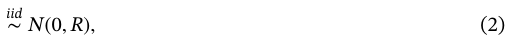

NOTE: contains mathematical notation; text above is the PDF text layer and symbols may be mis-extracted. Image shows the original.

in which *𝑓t* is an unobserved scalar factor, *𝛬*= [*𝜆*1*,* … *, 𝜆N*]<sup>′</sup> is an (*N* × 1) vector of factor loadings, *et* = [*e*1*,t,* … *, eN,t*]<sup>′</sup> is an *N*-dimensional process of disturbances, and *R* is a diagonal matrix with all diagonal elements being strictly positive. Then,*̂ zs,t* = *zs,t* if*̂ zs,t* is observed.

The factor *𝑓t* is our national-level WARN factor that affects all states through the factor loadings. We assume that *𝑓t* follows an AR(1) process,

**equation / math rendering (image)**

NOTE: contains mathematical notation; text above is the PDF text layer and symbols may be mis-extracted. Image shows the original.

*iid*∼*N*(0*, Q*)*,* (3)

**equation / math rendering (image)**

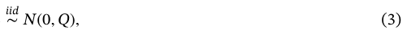

NOTE: contains mathematical notation; text above is the PDF text layer and symbols may be mis-extracted. Image shows the original.

in which *A* is the autoregression slope coefficient, *ut* is the autoregression innovation, and *Q >* 0. This AR(1) structure allows the WARN factor to be persistent, similar to other national-level labor market variables.<sup>11</sup> Equations (2) and (3) compose our DFM.

10We follow Camacho et al. (2015) and seasonally adjust {*xs,t*}*t*∈*s* for each state individually before estimating the DFM. We use the state-space model on page 80 of Wright (2013), with details in Appendix B.1 in the supporting information. In the not seasonally adjusted data, we find that mean WARN layoffs are high in January and low in December, which motivates our choice to seasonally adjust. We provide more discussion in Appendix B.2 in the supporting information.

11We find that using an AR(2) structure produces essentially the same factor as the AR(1) structure. For the July 1996 to November 2021 sample used for Figure 4, the correlation between factor estimates using an AR(1) and an AR(2) is 0.999995.

KROLIKOWSKI and LUNSFORD **469**

Page 9

**FIGURE 4** The Worker Adjustment and Retraining Notification (WARN) factor and *WARNt*. *Note:* The top panel has the estimated WARN factor from July 1996 to November 2021 with 95% confidence intervals. The factor is estimated using the method in Ba ´nbura and Modugno (2014). Standard errors are computed using the parametric bootstrap approach in Pfeffermann and Tiller (2005). The bottom panel has*̂ WARNt*, the number of WARN layoffs implied by the WARN factor, from July 1996 to November 2021. Vertical gray bars in both panels indicate NBER recession dates. See Section 4 for details.

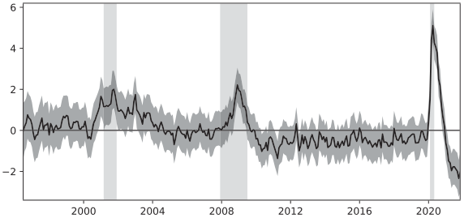

NOTE: figure/graphic rendered as an image from the PDF; its content is not machine-readable text. Caption (if any) follows as the next block.

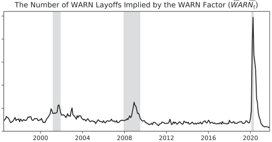

NOTE: figure/graphic rendered as an image from the PDF; its content is not machine-readable text. Caption (if any) follows as the next block.

We use a sample from July 1996 through November 2021 for the *N* = 28 states in Table 1 to estimate our WARN factor.<sup>12</sup>

Choosing our start date balances a long time series with having many states in the initial cross-section. We balance these two concerns by starting the sample in July 1996 when we observe data for five states: MI, NC, OH, VA, and WI.

When estimating the WARN factor, we normalize its unconditional variance to be 1 and discuss it in terms of its standard deviation. We use the parametric bootstrap in Pfeffermann and Tiller (2005) to compute the mean squared errors for the confidence intervals. We give details of the EM algorithm and confidence intervals in Appendix B.3 in the supporting information. We find that the estimated state factor loadings increase with average employment and manufacturing shares, as discussed in Appendix B.4 in the supporting information. We choose one factor based on the information criteria of Bai and Ng (2002), as discussed in Appendix B.5 in the supporting information.

Our WARN factor has three noteworthy features. First, it rises just before or in recessions, falls during the initial parts of expansions, and is relatively flat during later parts of expansions, as shown in the top panel of Figure 4. While it is typically near or below zero outside of recessions, it is significantly above zero for the 2001 recession, the subsequent slow labor market recovery, and the 2008–2009, and 2020 recessions. Second, the peak of the WARN factor is higher in the 2008–2009 recession than in the 2001 recession and higher in the 2020 recession than in the 2008–2009 recession, consistent with the relative severity of these recessions. Third, the WARN factor has few false positives: When it is one standard deviation or more above zero, it indicates increasing slack in the labor market.

It is useful to have an aggregate measure of WARN notice data with economically interpretable units because the units of the WARN factor are standard deviations. Toward this end, we compute the number of WARN layoffs implied by the

12We do not make any adjustments to our DFM for the COVID-19 pandemic. While we estimate our WARN factor through November 2021, most of our subsequent analysis in Sections 5 and 6 focuses on data through 2019. Further, when we estimate the WARN factor from July 1996 through December 2019, we get a correlation of 0.96 with the factor estimates shown in Figure 4 (top panel). Different methods for adjusting factor models to handle the COVID-19 pandemic have been proposed (Ng, 2020; Maroz et al., 2021). We leave the analysis of which method is best suited for WARN data to future research.

KROLIKOWSKI and LUNSFORD **470**

Page 10

**FIGURE 5** Comparing*̂ WARNt* and Mass Layoff Statistics (MLS). *Note:̂ WARNt* is in number of workers in thousands on the left scale. MLS number of initial claimants in thousands is on the right scale. The sample is July 1996 to May 2013 when MLS was discontinued. Shading represents NBER recession dates. See Section 5.1 for details.

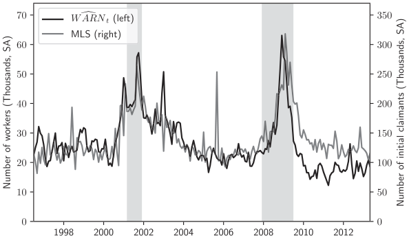

NOTE: figure/graphic rendered as an image from the PDF; its content is not machine-readable text. Caption (if any) follows as the next block.

**equation / math rendering (image)**

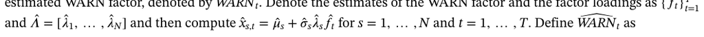

NOTE: contains mathematical notation; text above is the PDF text layer and symbols may be mis-extracted. Image shows the original.

**equation / math rendering (image)**

NOTE: contains mathematical notation; text above is the PDF text layer and symbols may be mis-extracted. Image shows the original.

**equation / math rendering (image)**

NOTE: contains mathematical notation; text above is the PDF text layer and symbols may be mis-extracted. Image shows the original.

**equation / math rendering (image)**

NOTE: contains mathematical notation; text above is the PDF text layer and symbols may be mis-extracted. Image shows the original.

The bottom panel of Figure 4 shows*̂ WARNt* from July 1996 to November 2021. It is highly correlated with the WARN factor (correlation of 0.86). However, because we take exponentials in Equation (4),*̂ WARNt* displays more skewness than the WARN factor, with larger peaks in recessions. This asymmetry better matches the US labor market data (e.g., see Ferraro, 2018), which may help explain why*̂ WARNt* improves unemployment rate forecasts more than the WARN factor in Section 6.<sup>13</sup>

#### **5 IN-SAMPLE PROPERTIES OF THE WARN FACTOR**

#### **5.1 Comparison to MLS and JOLTS**

Figure 5 shows*̂ WARNt* and the number of initial UI claimants from the MLS from July 1996, when*̂ WARNt* begins, to May 2013, when the MLS data end. The two series are positively correlated (correlation of 0.64) and have similar business cycle properties. Both series increased in the second half of 2000, leading up to the 2001 recession, and both series spiked in September 2001 during the September 11, 2001 terrorist attacks. Both series declined slowly from 2002 to 2004, coinciding with a slow labor market recovery.*̂ WARNt* slightly leads the MLS data in the 2008-09 recession. Overall, when filtered through the DFM, the WARN data align well with the aggregate properties of the MLS data despite fewer states reporting WARN data earlier in our sample.<sup>14</sup>

Figure 6 shows*̂ WARNt* and the number of JOLTS private layoffs and discharges from December 2000, when the JOLTS data begin, to December 2019.<sup>15</sup> We display the JOLTS data in two panels by establishment size: 50 employees or more in the top panel and 49 employees or less in the bottom panel. The top panel shows that*̂ WARNt* correlates highly with layoffs

13We compare*̂ WARNt* to the sum of WARN layoffs from a balanced panel of states since January 2006, used in Figures 2 and 3, in Appendix B.6 in the supporting information. The two series are close in levels and highly correlated.

14The large spike in the MLS series in September 2005 reflects the impact of Hurricane Katrina in Louisiana and Mississippi (BLS, 2005). These states enter our sample in 2007 and 2010, respectively, so the WARN series does not reflect the impact of that hurricane.

15We do not show data for 2020 because the scale is so large that data fluctuations prior to 2020 become difficult to see, as shown in Figure A7.

KROLIKOWSKI and LUNSFORD **471**

Page 11

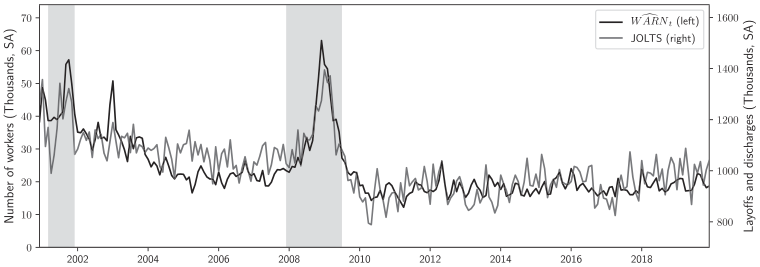

NOTE: figure/graphic rendered as an image from the PDF; its content is not machine-readable text. Caption (if any) follows as the next block.

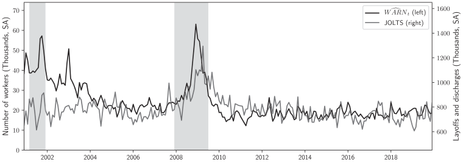

NOTE: figure/graphic rendered as an image from the PDF; its content is not machine-readable text. Caption (if any) follows as the next block.

**FIGURE 6** Comparing*̂ WARNt* and Job Openings and Labor Turnover Survey (JOLTS). *Note:̂ WARNt* is in number of workers in thousands on the left scale. It is the same in both panels. In the top panel, JOLTS private layoffs and discharges in thousands are for establishments with 50 workers or more and are on the right axis. In the bottom panel, JOLTS private layoffs and discharges in thousands are for establishments with 49 workers or less and are on the right axis. The sample is December 2000 to December 2019 in both panels. Shading represents NBER recession dates. See Section 5.1 for details.

and discharges at larger establishments (correlation of 0.81). In addition, layoffs and discharges at larger establishments have a downward trend over this sample and are generally lower from 2010 to 2019 than from 2002 to 2007. This decline matches a downward trend in the WARN data and is consistent with evidence about the secular decline in job loss rates over the last 40 years (Davis, 2008; Elsby et al., 2009; Shimer, 2012). As with the MLS data, the WARN data align well with the aggregate properties of JOLTS layoffs and discharges at larger establishments.

The bottom panel of Figure 6 shows that*̂ WARNt* correlates less highly with layoffs and discharges at smaller establishments (correlation of 0.38). This result is consistent with the WARN Act only applying to larger firms.

#### **5.2 A VAR with unemployment flows**

In this section, we provide statistical evidence that WARN data are a useful labor market indicator when included in the VAR from Barnichon and Nekarda (2012), henceforth BN.

We first introduce some additional notation and data. Let *gt* and *st* be the job finding rate and the job separation rate between month *t* −1 and month *t*. We compute *gt* and *st* as in BN and Shimer (2012), with details in Appendix C in the supporting information. The vector of the data in the VAR is

*Yt* = [100 × ln(*gt*)*,* 100 × ln(*st*)*,* 100 × Δ ln(*urt*)*,* 100 × ln(*uict*)*,* Δ*pet,* Δ*̂WARNt*∕1000]<sup>′</sup>*,*

**equation / math rendering (image)**

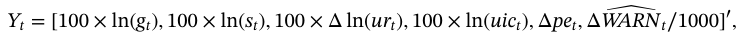

NOTE: contains mathematical notation; text above is the PDF text layer and symbols may be mis-extracted. Image shows the original.

in which *urt* denotes the unemployment rate, *uict* denotes initial UI claims, and *pet* denotes private employment. The VAR is

KROLIKOWSKI and LUNSFORD **472**

Page 12

**TABLE 3** VAR regression coefficients on lags of Δ*̂WARNt*.

**(1) (2) (3) (4) (5) (6)**

**ln(*gt*) ln(*st*) 𝚫ln(*urt*) ln(*uict*) 𝚫*pet* 𝚫*̂WARNt***

**equation / math rendering (image)**

NOTE: contains mathematical notation; text above is the PDF text layer and symbols may be mis-extracted. Image shows the original.

Δ*̂WARNt*−1 0.00 0.28** 0.08** 0.17* −2.24 0.05 (0.13) (0.11) (0.04) (0.09) (2.56) (0.08) Δ*̂WARNt*−2 −0.04 0.04 0.03 0.12 −2.19 −0.14* (0.12) (0.09) (0.03) (0.08) (1.72) (0.08)

*Note*: Regression coefficients for Equation (5), estimated by least squares. Standard errors are in parentheses and are heteroskedasticity robust. See Section 5.2 for details.

Abbreviations: VAR, vector autoregression; WARN, Worker Adjustment and Retraining Notification.****p <* 0*.*01.

***p <* 0*.*05.

**p <* 0*.*1.

*Yt* = Γ0 + Γ1*Yt*−1 + Γ2*Yt*−2 + *𝜁t,* (5)

**equation / math rendering (image)**

NOTE: contains mathematical notation; text above is the PDF text layer and symbols may be mis-extracted. Image shows the original.

in which Γ0 is a (6 × 1) vector and Γ1 and Γ2 are (6 × 6) matrices. We use logs and differences in the first four rows of this VAR to match BN. In addition, we scale the first four rows by 100 so that the data can be interpreted in terms of percent or percent changes. We also use two lags to match BN. The substantive difference between this VAR and the VAR in BN is the fifth and sixth rows, in which we include Δ*pet* and Δ*̂WARNt*∕1000.<sup>16</sup> We estimate the VAR from August 1996 to December 2019. Ending the sample in 2019 gives better intuition for the forecasting results in Section 6.2.

The regression coefficients on the lags of Δ*̂WARNt* appear in Table 3. The first lag of Δ*̂WARNt* is statistically significant for the log separation rate even controlling for the other regressors in the VAR. As such, WARN data correlate highly with job loss data from the CPS, in addition to those from MLS and JOLTS, as previously shown in Figures 5 and 6. Consistent with our earlier research (Krolikowski et al., 2019), Table 3 also shows that the first lag of Δ*̂WARNt* is statistically significant for the log change in the unemployment rate and log initial UI claims.

To facilitate interpretation of these VAR results, we show IRFs to a surprise increase in*̂ WARNt* in Figure 7. We implement this with a one standard deviation increase in the element of *𝜁t* in the sixth row of the VAR, while all other elements of *𝜁t* are zero. We then use the VAR coefficients (excluding Γ0) to iterate *Yt* forward. In Figure 7, month 0 on the horizontal axis shows the initial increase in*̂ WARNt* and all subsequent months show the responses of the other variables. The shaded region in each panel shows the 95% confidence intervals.<sup>17</sup>

Consistent with the results in Table 3, the job separation rate, the unemployment rate, and initial UI claims increase in month 1, following a surprise increase in*̂ WARNt* in month 0. There is noise in the job separation rate in month 2, but subsequently, the separation rate stays persistently elevated. To aid interpretation, we accumulate the unemployment rate IRF and show it in percent rather than percent changes. After month 1, the unemployment rate gradually rises and peaks at 0.88% just after 2 years. Initial UI claims peak at month 2 and stay persistently elevated. Changes in private employment fall sharply in months 1 and 2 but with a high level of uncertainty. Beginning in month 3, changes in private employment are statistically significantly negative but move back toward zero. Finally, the job finding rate does not change in the short-run, but it does have a statistically significant drop after about 20 months.

While the WARN Act only requires 60 days' advanced layoff notice, the IRFs indicate that WARN layoffs can help forecast the labor market at longer horizons. In particular, the peak responses of several variables occur at horizons extending well beyond the WARN Act's 60-day advance notice period. These longer-horizon responses occur because the VAR's system of equations allows the non-WARN variables to affect each other after the initial, short-lived change in WARN layoffs.

These IRFs are in-sample estimates and do not necessarily imply that WARN layoffs are useful in real time. In particular, the WARN factor is estimated using data through November 2021 and may provide a more accurate estimate of

16BN use the change in the log of the help wanted index (HWI) from Barnichon (2010). We have found that this HWI is only updated sporadically and so do not use it.

17We bootstrap our confidence intervals following Runkle (1987). We resample the VAR residuals with replacement to produce bootstrapped VAR innovations. We use these innovations with the estimates of Γ0*,* Γ1, and Γ2 and the initial conditions *Y* <sup>∗</sup>

**equation / math rendering (image)**

NOTE: contains mathematical notation; text above is the PDF text layer and symbols may be mis-extracted. Image shows the original.

*t*=−1<sup>. We use this artificial sample to estimate new IRFs, including a new estimate of the standard deviation of the sixth element of</sup> *𝜁t*. We repeat this process 5000 times, sort the bootstrapped IRFs at each horizon, and show the 125th and 4875th sorted IRFs as the confidence intervals.

KROLIKOWSKI and LUNSFORD **473**

Page 13

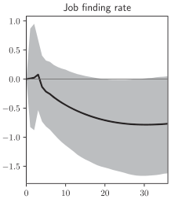

NOTE: figure/graphic rendered as an image from the PDF; its content is not machine-readable text. Caption (if any) follows as the next block.

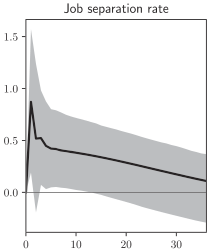

NOTE: figure/graphic rendered as an image from the PDF; its content is not machine-readable text. Caption (if any) follows as the next block.

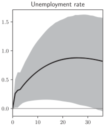

NOTE: figure/graphic rendered as an image from the PDF; its content is not machine-readable text. Caption (if any) follows as the next block.

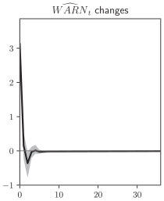

NOTE: figure/graphic rendered as an image from the PDF; its content is not machine-readable text. Caption (if any) follows as the next block.

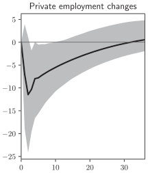

NOTE: figure/graphic rendered as an image from the PDF; its content is not machine-readable text. Caption (if any) follows as the next block.

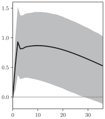

NOTE: figure/graphic rendered as an image from the PDF; its content is not machine-readable text. Caption (if any) follows as the next block.

**FIGURE 7** Impulse response functions (IRFs) to a surprise increase in*̂ WARNt*. *Note:* IRFs produced iteratively from the estimated vector autoregression (VAR) in Equation (5). Solid lines show the point estimates, and shaded regions show the 95% confidence intervals. Confidence intervals are produced with a bootstrap (Runkle, 1987). See Section 5.2 for details.

WARN layoffs than is available in real time. In the next section, we show that WARN layoffs are informative even in a pseudo real-time forecasting exercise. Further, our IRFs provide intuition for the horizons at which WARN layoffs improve forecasting ability.

#### **6 PSEUDO REAL-TIME FORECASTING**

#### **6.1 Forecasting models**

We forecast the unemployment rate with two methods and changes in private employment with one method. In particular, we use the VAR in Equation (5) to forecast both the unemployment rate and changes in private employment, and we also use BN's labor flows model to forecast the unemployment rate. We do not use other forecasting models from, for example, Montgomery et al. (1998).<sup>18</sup>

For the VAR forecasts, we use data through period *t*−1 and estimates of the VAR coefficients to iterate the VAR forward to produce forecasts of Δ ln(*urt*)*,* Δ ln(*urt*+1)*,* … . These forecasts along with the realized value *urt*−1 allow us to compute forecasts of the unemployment rate, which we denote with*̂ urt*|*t*−1*,̂ urt*+1|*t*−1*,* … . Iterating the VAR forward also produces forecasts of Δ*pet,* Δ*pet*+1*,* … , which we denote with*̂ pet*|*t*−1*,̂ pet*+1|*t*−1*,* … .

18We do this for two reasons. First, no model studied in Montgomery et al. (1998) is more accurate than the Survey of Professional Forecasters (SPF) forecasts, but BN find that their flows model is more accurate than SPF forecasts. Hence, we consider BN's labor flows model to be the state of the art for forecasting the unemployment rate. Second, in contrast to the models studied in Montgomery et al. (1998) which have no labor flows, the VAR and BN's labor flows model emphasize the importance of labor flows for modeling the unemployment rate. We have shown that WARN data have different implications for job finding and job separation rates (e.g., see Figure 7).

KROLIKOWSKI and LUNSFORD **474**

Page 14

BN's labor market flows model uses

**equation / math rendering (image)**

NOTE: contains mathematical notation; text above is the PDF text layer and symbols may be mis-extracted. Image shows the original.

**equation / math rendering (image)**

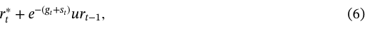

NOTE: contains mathematical notation; text above is the PDF text layer and symbols may be mis-extracted. Image shows the original.

**equation / math rendering (image)**

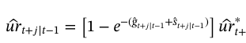

NOTE: contains mathematical notation; text above is the PDF text layer and symbols may be mis-extracted. Image shows the original.

**equation / math rendering (image)**

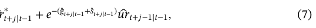

NOTE: contains mathematical notation; text above is the PDF text layer and symbols may be mis-extracted. Image shows the original.

We produce six collections of forecasts from the VAR: three collections for unemployment rate forecasts and three collections for employment change forecasts. For both variables, one collection of forecasts uses only the first five variables in the VAR, a second collection adds the change in the WARN factor to the VAR, and a third collection adds Δ*̂WARNt* to the VAR. We refer to these forecasting models as VAR-5, VAR-f, and VAR-w.

We produce forecasts at 25 monthly horizons, *h* = 0*,* 1*,* … *,* 24. Our first collection of forecasts for January 2008 to January 2010 uses data through December 2007. We then move 1 month forward and produce forecasts for February 2008 to February 2010, using data through January 2008, and so on. For each month *t*, we use all available WARN data through *t* −1 for each state with at least 24 months of WARN data for seasonal adjustment.<sup>19</sup> Then, we use the seasonally adjusted WARN data from July 1996 through period *t* −1 to estimate the DFM and produce pseudo real-time estimates of the WARN factor and*̂ WARNt*−1. Finally, we use these pseudo real-time estimates of the WARN factor and*̂ WARNt*−1 along with real-time CPS, private employment, and initial UI claims data, to estimate the parameters of the VAR model and compute the forecasts.<sup>20</sup> We estimate the VAR using a rolling sample of 11 years and 5 months, instead of 15 years in BN, because the WARN factor begins in July 1996 and our first collection of forecasts uses data through December 2007.

#### **6.2 Forecasting results**

We evaluate our forecasts separately for two samples: January 2008 to December 2019 and January 2020 to December 2020. We separate the pre-2020 and post-2020 period for two reasons. First, labor market fluctuations in 2020 are so large that conventional forecast evaluation statistics based on squared forecast errors are overwhelmed by the 2020 observations. Second, we do not believe it is reasonable for any forecasting model or data series to have predicted the labor market fluctuations in 2020 at a multistep horizon.

Table 4 shows the forecast accuracy results for January 2008 to December 2019 for selected forecast horizons. It has three panels: Panels A and B present unemployment rate forecast results, and Panel C presents private employment forecast results. Row (1) shows the RMSPEs of the SSUR-baseline model when forecasting the unemployment rate.<sup>21</sup> The units in row (1) are percentage points of the unemployment rate. For example, for forecast horizon *h* = 0, the SSUR-baseline model's forecast errors average about 0.17 percentage points. Row (1) shows that these errors grow with the forecast horizon.

19For example, CA data begin in 2006m1 (Table 1). Hence, we have 24 observations for CA in December 2007. We then include CA data in the DFM estimation to make forecasts for January 2008 and later.

20We use real-time CPS data and private employment data from the Federal Reserve Bank of St. Louis's ALFRED database (ALFRED, 2022). We use real-time initial UI claims from ALFRED and the Department of Labor's archive of UI news releases (DOL, 2022). Because we began collecting the WARN notices in March 2019, we do not know the real-time nature of the ragged edge problem for much of our forecasting sample. For forecasts from 2008 through 2019, we use all WARN data through period *t* −1 when making forecasts of periods *t, t* + 1*,* … . For forecasts in 2020, we use the real-time WARN vintages, including the real-time ragged edge, when making our forecasts.

21We compute the RMSPEs as follows. First, let*̂ urt*+*h*|*t*−1 denote the forecasted unemployment rate at horizon *h*. Then,*̂ dh,t* = *urt*+*h* −*̂ urt*+*h*|*t*−1 is the

forecast error, in which *urt*+*h* is the most recent vintage of the *t* + *h* unemployment rate. Then, the RMSPE is

**equation / math rendering (image)**

NOTE: contains mathematical notation; text above is the PDF text layer and symbols may be mis-extracted. Image shows the original.

**equation / math rendering (image)**

NOTE: contains mathematical notation; text above is the PDF text layer and symbols may be mis-extracted. Image shows the original.

**equation / math rendering (image)**

NOTE: contains mathematical notation; text above is the PDF text layer and symbols may be mis-extracted. Image shows the original.

**equation / math rendering (image)**

NOTE: contains mathematical notation; text above is the PDF text layer and symbols may be mis-extracted. Image shows the original.

available forecast errors. Because we only evaluate the forecasts through December 2019 in Table 4, the number of available forecast errors in row (10) shrinks with the forecast horizon.

KROLIKOWSKI and LUNSFORD **475**

Page 15

**TABLE 4** Predictive accuracy of forecasting models without and with WARN data.

*h* = 0 *h* = 1 *h* = 2 *h* = 3 *h* = 4 *h* = 5 *h* = 6 *h* = 7 *h* = 8 *h* = 9 *h* = 12 *h* = 18 *h* = 24

**equation / math rendering (image)**

NOTE: contains mathematical notation; text above is the PDF text layer and symbols may be mis-extracted. Image shows the original.

Panel A: Unemployment rate forecast accuracy with SSUR models

(1) SSUR-baseline RMSPE 0.17 0.24 0.33 0.42 0.52 0.62 0.73 0.85 0.97 1.09 1.45 1.97 2.32 Relative RMSPEs of Other Forecasting Models:

(2) SSUR-f 1.00 1.00 0.99 0.99 0.99 0.98 0.98** 0.97** 0.97** 0.97** 0.96** 0.94** 0.93** (3) SSUR-w 1.00 0.99 0.98* 0.97*** 0.97** 0.96** 0.96** 0.95*** 0.95*** 0.94** 0.93** 0.90** 0.87** Panel B: Unemployment rate forecast accuracy with VAR models

(4) VAR-5 RMSPE 0.17 0.23 0.32 0.42 0.52 0.63 0.74 0.86 0.97 1.09 1.43 1.90 2.19 Relative RMSPEs of Other Forecasting Models:

(5) VAR-f 1.00 0.99 0.98 0.98* 0.98 0.97 0.97* 0.96* 0.96** 0.96* 0.95* 0.94* 0.92** (6) VAR-w 1.00 0.98 0.96** 0.96*** 0.95** 0.95** 0.94** 0.94** 0.93** 0.93** 0.92* 0.90* 0.87** Panel C: Private employment change forecast accuracy with VAR models

(7) VAR-5 RMSPE 121 137 165 176 195 206 219 228 236 237 236 190 183 Relative RMSPEs of Other Forecasting Models:

(8) VAR-f 1.02 1.02** 1.01 0.99 0.99 0.99 0.98 0.97** 0.97** 0.96*** 0.94*** 0.89*** 0.90** (9) VAR-w 1.00 1.01 1.00 0.98 0.99 0.98 0.97 0.96** 0.96** 0.95*** 0.91*** 0.82*** 0.83** (10) Evaluation sample size 144 143 142 141 140 139 138 137 136 135 132 126 120

*Note*: Rows (1) and (4) show the root mean squared prediction errors (RMSPEs) of the SSUR-baseline forecasting model and the five-variable VAR model when forecasting the unemployment rate for each

horizon, *h*. The units can be interpreted as unemployment rate percentage points. Rows (2) and (3) show the ratios of the RMSPEs from the corresponding models to the SSUR-baseline model. Values less

than 1 indicate lower RMSPEs than the SSUR-baseline model. Rows (5) and (6) show the ratios of the RMSPEs from the corresponding models to the five-variable VAR model. Values less than 1 indicate

lower RMSPEs than the five-variable VAR model. Row (7) shows the RMSPEs of the five-variable VAR model when forecasting changes in private employment. The units can be interpreted as number of

employees in thousands. Rows (8) and (9) show the ratios of the RMSPEs from the corresponding models to the five-variable VAR model. Values less than 1 indicate lower RMSPEs than the five-variable

VAR model. Row (10) shows the evaluation sample sizes for all panels. The sample period for the forecast errors is January 2008 to December 2019. See Section 6 for details.

Abbreviations: SSUR, steady-state unemployment rate; VAR, vector autoregression; WARN, Worker Adjustment and Retraining Notification.****p <* 0*.*01.

***p <* 0*.*05.

**p <* 0*.*1.

KROLIKOWSKI and LUNSFORD **476**

Page 16

Rows (2) and (3) of Table 4 show the RMSPEs from the competing forecasting models divided by the RMSPEs from the SSUR-baseline model in row (1). Values less (greater) than 1 indicate that the competing model is more (less) accurate than the SSUR-baseline model. The results in rows (2) and (3) show that including either the WARN factor or*̂ WARNt* in the SSUR model can generate statistically significant forecast improvements.<sup>22</sup> The model with*̂ WARNt* performs slightly better than the model with the WARN factor. With*̂ WARNt*, forecast improvements are statistically significant at *h* = 2 and beyond. RMSPE reductions generally get bigger with the forecast horizon and are 10% or larger at longer horizons.

The IRFs in Figure 7 provide intuition for the horizon of the forecast improvements. The SSUR models use labor market flows to construct unemployment rate forecasts. In Figure 7, a surprise change in*̂ WARNt* implies consistently statistically significant changes in the job separation rate at horizon 3 and after. Further, Figure 7 shows that a surprise increase in *WARNt* implies increasingly negative effects on the job finding rate beyond horizon 3, although statistical significance does not occur until after 20 months. Hence, WARN layoffs give the largest improvements in the SSUR model at longer horizons. Forecast evaluation results for the job separation and finding rates align with this intuition (Appendix D.3 in the supporting information).

Row (4) shows the RMSPEs of the five-variable VAR model when forecasting the unemployment rate. Rows (5) and (6) show that including WARN data improves the forecast accuracy of the VAR models and that*̂ WARNt* improves the accuracy slightly more than the WARN factor. The statistically significant forecast improvements occur at horizon *h* = 2 and grow with *h*, as in Panel A. This roughly aligns with the in-sample IRFs in Figure 7. In that figure, an increase in*̂ WARNt* in month 0 precedes an increase in the unemployment rate in month 1 and a continued gradual rise in the unemployment rate out to about 2 years.

Row (7) shows the RMSPEs of the five-variable VAR model when forecasting changes in private employment. Rows (8) and (9) show that including WARN data improves forecasts at longer horizons and using*̂ WARNt* gives larger improvements than using the WARN factor, consistent with the results for the unemployment rate. In Appendix D.4 in the supporting information, we show that forecasting improvements with WARN data are diminished when we subtract manufacturing employment from private employment. These findings are consistent with our findings that WARN notices tilt toward manufacturing establishments and that loadings in the factor model generally increase with the share of manufacturing employment.

Overall, Table 4 highlights the real-time usefulness of WARN data for monitoring the labor market. WARN data provide statistically significant forecast improvements for the unemployment rate when using both the SSUR model, which forecasts the unemployment rate as a function of labor market flows, and the VAR model, which includes the unemployment rate directly. WARN data also provide statistically significant forecast improvements for changes in private employment. Further, in Appendix D.5 in the supporting information we highlight some robustness features of our results. First, our results do not materially change for different choices of estimation and evaluation samples. Second, WARN layoffs continue to yield statistically significant RMSPE reductions with direct forecasts.

Turning to the 2020 sample, we do not believe it is reasonable for any forecasting model or data series to have predicted the labor market fluctuations in 2020 at a multistep horizon and so only discuss the *h* = 0 horizon. We find that WARN

**equation / math rendering (image)**

NOTE: contains mathematical notation; text above is the PDF text layer and symbols may be mis-extracted. Image shows the original.

**equation / math rendering (image)**

NOTE: contains mathematical notation; text above is the PDF text layer and symbols may be mis-extracted. Image shows the original.

KROLIKOWSKI and LUNSFORD **477**

Page 17

data do not materially alter the accuracy of 2020 nowcasts from the VAR or SSUR models, as shown in Appendix D.6 in the supporting information. These findings are consistent with our results for 2008–2019, in which WARN data do not affect RMSPEs at the *h* = 0 horizon.

#### **7 CONCLUSION**

Previous research has documented that job loss is important for understanding aggregate unemployment fluctuations. We compile a unique database of about 75,000 establishment-level WARN notices about impending layoffs. Our data cover 33 US states, and, for many large states, our data begin in the 1990s. We aggregate these data to the state level and establish that they are a useful indicator of aggregate job loss. We find that the number of workers affected by WARN notices (“WARN layoffs”) leads other state labor market indicators, such as initial UI claims and changes in the unemployment rate and private employment. The lead relationship is strongest in the two months following WARN notification, consistent with the 60 days' notice required by the WARN Act. Using a DFM, we aggregate the unbalanced state-level data to a national-level indicator of job loss (the “WARN factor”). WARN layoffs implied by our factor correlate highly with MLS and JOLTS layoffs. IRFs from an in-sample VAR show that the job separation rate and the unemployment rate from the CPS, as well as initial UI claims, increase immediately and persistently following a surprise increase in WARN layoffs implied by our factor. A pseudo real-time forecasting exercise shows that changes in WARN layoffs implied by our factor improve the accuracy of unemployment rate forecasts from 2008 to 2019 in both a VAR and the flows model in Barnichon and Nekarda (2012). We also find that WARN layoffs improve forecast accuracy for private employment changes.

We update state-level WARN layoffs and the WARN factor twice a month and make these real-time data publicly available (Krolikowski & Lunsford, 2022). Policymakers and economists can use our data to monitor job loss in real time and to predict unemployment fluctuations.

#### **ACKNOWLEDGMENTS**

The idea for this project grew out of early conversations with Andrew Foote. We thank Regis Barnichon, Todd Clark, Mike Elsby, Bruce Fallick, Domenico Giannone, Ed Knotek, Andreas Mueller, Juan Rubio-Ramirez, Peter Rupert, Ay¸segül

¸Sahin, Kenneth West, and Saeed Zaman for helpful advice and conversations. We also thank seminar participants at the Federal Reserve Bank of Cleveland and participants at several conferences. Daniela Dean Avila, Matthew Gordon, Angela Guo, Anna Weixel, and Meifeng Yang provided excellent research assistance. The views expressed in this paper are solely the responsibility of the authors and should not be interpreted as reflecting the views of the Board of Governors, the Federal Reserve Bank of Cleveland, or the Federal Reserve System.

#### **OPEN RESEARCH BADGES**

This article has been awarded Open Data Badge for making publicly available the digitally-shareable data necessary to reproduce the reported results. Data is available at https://doi.org/10.15456/jae.2023234.1724061840.

#### **DATA AVAILABILITY STATEMENT**

We have made the data and replication files for this paper available.

#### **REFERENCES**

ALFRED (2022). Archival economic data. Accessed: January 21, 2022. Ahn, H. J., Chen, H., & Kister, M. (2020). A new indicator of common wage inflation. FEDS Notes. Washington: Board of Governors of the

Federal Reserve System, July 08, 2020. Ahn, H. J., & Fulton, C. (2020). Index of common inflation expectations. FEDS Notes. Washington: Board of Governors of the Federal Reserve

System, September 02, 2020. Auray, S., Fuller, D. L., & Lkhagvasuren, D. (2019). Unemployment insurance take-up rates in an equilibrium search model. *European Economic*

*Review*, *112*, 1–31. BLS (2005). Mass layoffs in September 2005. Accessed: December 9, 2020. BLS (2022). Employment situation summary. Accessed: January 28, 2022. Bai, J., & Ng, S. (2002). Determining the number of factors in approximate factor models. *Econometrica*, *70*(1), 191–221.

KROLIKOWSKI and LUNSFORD **478**

Page 18

Ba ´nbura, M., Giannone, D., Modugno, M., & Reichlin, L. (2013). Now-casting and the real-time data flow. In Elliott, G., & Timmermann, A.

(Eds.), *Handbook of economic forecasting*: Elsevier, pp. 195–237. Ba ´nbura, M., & Modugno, M. (2014). Maximum likelihood estimation of factor models on datasets with arbitrary pattern of missing data.

*Journal of Applied Econometrics*, *29*(1), 133–160. Barnichon, R. (2010). Building a composite help-wanted index. *Economics Letters*, *109*(3), 175–178. Barnichon, R. (2012). Vacancy posting, job separation and unemployment fluctuations. *Journal of Economic Dynamics and Control*,

*2012*, 315–330. Barnichon, R., & Nekarda, C. J. (2012). The ins and outs of forecasting unemployment: using labor force flows to forecast the labor market.

*Brookings Papers on Economic Activity*, 83–117. Available at https://www.jstor.org/stable/41825365 Blank, R. M., & Card, D. E. (1991). Recent trends in insured and uninsured unemployment: Is there an explanation?note=. *The Quarterly*

*Journal of Economics*, *106*(4), 1157–1189. https://www.jstor.org/stable/2937960 Cajner, T., Crane, L. D., Decker, R. A., Grigsby, J., Hamins-Puertolas, A., Hurst, E., Kurz, C., & Yildirmaz, A. (2020). The US labor market

during the beginning of the pandemic recession. *Brookings Papers on Economic Activity*, *Summer*, 3–33. Cajner, T., Figura, A., Price, B. M., Ratner, D., & Weingarden, A. (2020). Reconciling unemployment claims with job losses in the first months

of the COVID-19 crisis. Finance and Economics Discussion Series 2020-055. Washington: Board of Governors of the Federal Reserve System. Camacho, M., Lovcha, Y., & Pérez Quirós, G. (2015). Can we use seasonally adjusted variables in dynamic factor models?. *Studies in Nonlinear*

*Dynamics & Econometrics*, *19*(3), 377–391. Census (2019). 2019 Business dynamics statistics data tables. Accessed: January 31, 2022. “Firm Size” dataset. Chetty, R., Friedman, J. N., Hendren, N., Stepner, M., & The Opportunity Insights Team (2020). Addressing COVID-19 outliers in BVARs with

stochastic volatility. NBER Working Paper 27431. Claims, U. I. (2022). Initial claims, NSA. Accessed: January 13, 2022. Retrieved from FRED. Clark, T., & McCracken, M. (2013). Advances in forecast evaluation. In Elliott, G., & Timmermann, A. (Eds.), *Handbook of economic forecasting*:

Elsevier B.V., pp. 1107–1201. Coibion, O., Gorodnichenko, Y., & Weber, M. (2020). Labor markets during the COVID-19 Crisis: A preliminary view. NBER Working Paper

27017. Coles, M. G., & Moghaddasi Kelishomi, A. (2018). Do job destruction shocks matter in the theory of unemployment? *American Economic*

*Journal: Macroeconomics*, *10*(3), 118–136. DOL (2022). Unemployment insurance weekly claims reports archive. Retrieved on September 9, 2022. Davis, S. J. (2008). The decline of job loss and why it matters. *American Economic Review*, *98*(2), 263–267. Diebold, F. X., & Mariano, R. S. (1995). Comparing predictive accuracy. *Journal of Business & Economic Statistics*, *13*(3), 253–263. Dvorkin, M., & Isaacson, M. (2021). Assessing labor market conditions using high-frequency data. *Federal Reserve Bank of St. Louis Review*,

*103*(4), 461–76. Ehrenberg, R. G., & Jakubson, G. H. (1990). Why WARN? Plant closing legislation. *Regulation Summer*, *1990*, 39–46. Elsby, M. W. L., Michaels, R., & Solon, G. (2009). The ins and outs of cyclical unemployment. *American Economic Journal: Macroeconomics*,

*1*(1), 84–110. Ferraro, D. (2018). The asymmetric cyclical behavior of the US labor market. *Review of Economics Dynamics*, *30*, 145–162. Forsythe, E., Kahn, L. B., Lange, F., & Wiczer, D. (2020). Labor demand in the time of COVID-19: Evidence from vacancy postings and

UI claims. *Journal of Public Economics*, *189*, 104238. GAO (1993). Worker adjustment and retraining notification act not meeting its goals. GAO/HRD-93-18, Washington, D.C., February 23. GAO (2003). The worker adjustment and retraining notification act: Revising the act and educational materials could clarify employer

responsibilities and employee rights. GAO-03-1003, Washington, D.C., September 19. Giacomini, R., & Rossi, B. (2010). Forecast comparisons in unstable environments. *Journal of Applied Econometrics*, *25*(4), 595–620. Giacomini, R., & White, H. (2006). Tests of conditional predictive ability. *Econometrica*, *74*(6), 1545–1578. Hall, R. E., & Kudlyak, M. (2020). Why has the US economy recovered so consistently from every recession in the past 70 years? Federal Reserve

Bank of San Francisco Working Paper 2020-20. Harvey, D., Leybourne, S., & Newbold, P. (1997). Testing the equality of prediction mean squared errors. *International Journal of Forecasting*,

*13*(2), 281–291. Hernández-Murillo, R., & Krolikowski, P. (2020). Assessing layoffs in four midwestern states during the pandemic recession. Federal Reserve

Bank of Cleveland Economic Commentary, 2020-21. Hobijn, B., & ¸Sahin, A. (2011). Do initial claims overstate layoffs?. FRBSF Economic Letter, https://www.frbsf.org/economic-research/

publications/economic-letter/2011/february/claims-layoffs-overstated/ JOLTS (2022). Layoffs and discharges: Total private, SA. Accessed: January 13, 2022. Retrieved from FRED. Krolikowski, P. M., & Lunsford, K. G. (2022). Advance layoff notice data from the WARN act. Ann Arbor, MI: Inter-university Consortium for

Political and Social Research [distributor], 2022-01-26. Krolikowski, P. M., Lunsford, K. G., & Yang, M. (2019). Using advance layoff notices as a labor market indicator. Federal Reserve Bank of

Cleveland Economic Commentary, no. 2019-21. Kudlyak, M., & Wolcott, E. (2020). Pandemic layoffs. Working paper. Available at https://sites.google.com/site/erinwolcott/research Kurmann, A., Lalé, E., & Ta, L. (2021). The impact of COVID-19 on small business dynamics and employment: Real-time estimates with

homebase data. Working paper. https://etiennelale.weebly.com/uploads/1/0/1/6/101665630/hbdraft_latest.pdf

KROLIKOWSKI and LUNSFORD **479**

Page 19

Luciani, M. (2020). Common and idiosyncratic inflation. https://doi.org/10.17016/FEDS.2020.024“ Finance and Economics Discussion Series

2020-024. Washington: Board of Governors of the Federal Reserve System. Maroz, D., Stock, J. H., & Watson, M. W. (2021). Comovement of economic activity during the Covid recession. Working Paper, Princeton

University, December 15, 2021 version downloaded from https://www.princeton.edu/~mwatson/papers/Covid_Factor_20211215.pdf on January 6, 2023. Montgomery, A. L., Zarnowitz, V., Tsay, R. S., & Tiao, G. C. (1998). Forecasting the U.S. unemployment rate. *Journal of the American Statistical*

*Association*, *93*(442), 478–493. NY WARN (2019). New York State worker adjustment and retraining notification. Accessed: September 10, 2019. Ng, S. (2020). Modeling macroeconomic variations after Covid-19. NBER Working Paper 29060. OECD (2020). Temporary employment. Accessed: January 21, 2021. Pfeffermann, D., & Tiller, R. (2005). Bootstrap approximation to prediction MSE for state space models with estimated parameters. *Journal*

*of Time Series Analysis*, *26*(6), 893–916. Runkle, D. E. (1987). Vector autoregressions and reality. *Journal of Business & Economic Statistics*, *5*(4), 437–442. Shimer, R. (2012). Reassessing the ins and outs of unemployment. *Review of Economic Dynamics*, *12*(2), 127–148. Solon, G., Haider, S. J., & Wooldridge, J. M. (2013). What are we weighting for? *Journal of Human Resources*, *50*(2), 301–316. Vroman, W. (2009). Unemployment insurance recipients and nonrecipients in the CPS. Monthly Labor Review, https://www.bls.gov/opub/

mlr/2009/10/art4full.pdf Wright, J. H. (2013). Unseasonal seasonals? *Brookings Papers on Economic Activity Fall*, *2013*, 65–110.

#### **SUPPORTING INFORMATION**

Additional supporting information can be found online in the Supporting Information section at the end of the article.

**How to cite this article:** Krolikowski, P. M., & Lunsford, K. G. (2024). Advance layoff notices and aggregate job loss, *Journal of Applied Econometrics*, *39*(3), 462–480. https://doi.org/10.1002/jae.3032

KROLIKOWSKI and LUNSFORD **480**